# STAT420 Zobreth Group Project

#### Data Tendency

*What do sales look like, on average, for each geographic area and based on platform?*

```r
mean_sales_platform = aggregate(cbind(EU_Sales, JP_Sales, Other_Sales) ~ Platform, vgsales, mean)
print(mean_sales_platform)
```

```
##    Platform    EU_Sales     JP_Sales  Other_Sales
## 1      2600 0.041896552 0.0000000000 0.0072413793
## 2       3DO 0.000000000 0.0333333333 0.0000000000
## 3       3DS 0.116600000 0.1946000000 0.0251000000
## 4        DC 0.032500000 0.1646153846 0.0051923077
## 5        DS 0.091027205 0.0820919325 0.0282692308
## 6        GB 0.489793814 0.8775257732 0.0841237113
## 7       GBA 0.091972873 0.0574106042 0.0093834772
## 8        GC 0.070701107 0.0393726937 0.0094649446
## 9       GEN 0.204444444 0.0988888889 0.0329629630
## 10       GG 0.000000000 0.0400000000 0.0000000000
## 11      N64 0.129841772 0.1068354430 0.0136392405
## 12      NES 0.215816327 1.0066326531 0.0541836735
## 13       NG 0.000000000 0.1200000000 0.0000000000
## 14       PC 0.145959703 0.0001802757 0.0258006363
```

[output cut: 17 more lines]

**Assuming our company only cares about platforms from 2010 onward, we can focus on newer systems**

```r
# utilizing domain knowledge to filter platforms to only newer ones
new_platforms = c('X360', 'Wii', 'WiiU', 'XOne', 'PS3', 'PS4', 'PSV', '3DS', 'PC')
# filter data frame to include only specified platforms
vgsales_filtered = vgsales[vgsales$Platform %in% new_platforms, ]

mean_sales_platform_filtered = aggregate(cbind(EU_Sales, JP_Sales, Other_Sales) ~ Platform, vgsales_filtered, mean)
print(mean_sales_platform_filtered)
```

```
##   Platform   EU_Sales     JP_Sales Other_Sales
## 1      3DS 0.11660000 0.1946000000  0.02510000
## 2       PC 0.14595970 0.0001802757  0.02580064
## 3      PS3 0.26109663 0.0607438650  0.10798313
## 4      PS4 0.36925373 0.0425970149  0.12943284
## 5      PSV 0.03968293 0.0509024390  0.02051220
## 6      Wii 0.20492248 0.0529302326  0.06139535
## 7     WiiU 0.16944056 0.0894405594  0.04510490
## 8     X360 0.22510931 0.0099595142  0.06855870
## 9     XOne 0.21431925 0.0015962441  0.05596244
```

Of the newer platforms, which are most popular in each geographic region?

```r
# Find the platforms with highest mean sales in each region
highest_EU_platform = mean_sales_platform_filtered$Platform[which.max(mean_sales_platform_filtered$EU_Sales)]
highest_JP_platform = mean_sales_platform_filtered$Platform[which.max(mean_sales_platform_filtered$JP_Sales)]
highest_Other_platform = mean_sales_platform_filtered$Platform[which.max(mean_sales_platform_filtered$Other_Sales)]

highest_EU_sales = max(mean_sales_platform_filtered$EU_Sales)
highest_JP_sales = max(mean_sales_platform_filtered$JP_Sales)
highest_Other_sales <- max(mean_sales_platform_filtered$Other_Sales)

cat("Platform with highest mean sales in EU: ", highest_EU_platform, " (", highest_EU_sales, ")", "\n")
```

```
## Platform with highest mean sales in EU:  PS4  ( 0.3692537 )
```

```r
cat("Platform with highest mean sales in JP: ", highest_JP_platform, " (", highest_JP_sales, ")", "\n")
```

```
## Platform with highest mean sales in JP:  3DS  ( 0.1946 )
```

```r
cat("Platform with highest mean sales in Other regions: ", highest_Other_platform, "(", highest_Other_sales, ")", "\n")
```

```
## Platform with highest mean sales in Other regions:  PS4 ( 0.1294328 )
```

#### Data Distribution

Sales by Genre

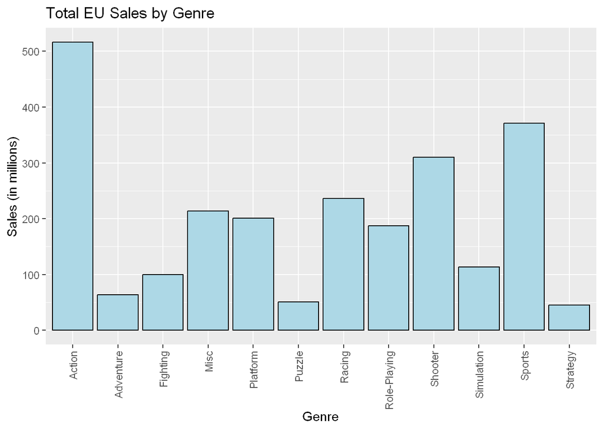

```r
# Aggregate total sales
eusales_agg = aggregate(EU_Sales ~ Genre, vgsales, sum)
jpsales_agg = aggregate(JP_Sales ~ Genre, vgsales, sum)
othersales_agg = aggregate(Other_Sales ~ Genre, vgsales, sum)

# EU Sales
ggplot(eusales_agg, aes(x = Genre, y = EU_Sales)) +geom_bar(stat = "identity", fill = "lightblue", color = "black") + theme(axis.text.x = element_text(angle = 90, vjust = 0.5, hjust=1)) + labs(x = "Genre", y = "Sales (in millions)", title = "Total EU Sales by Genre")
```

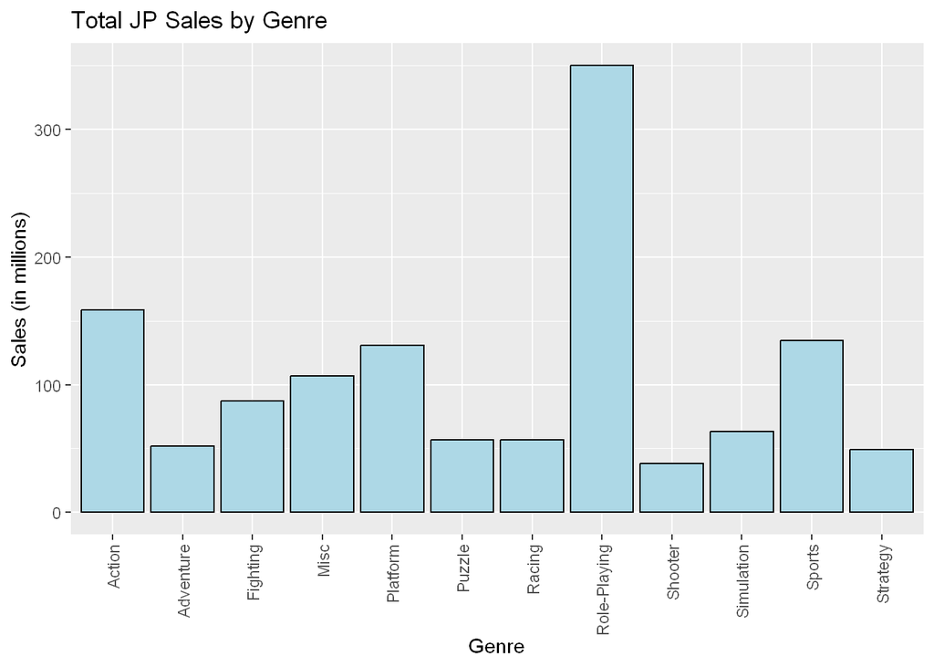

```r
# JP Sales
ggplot(jpsales_agg, aes(x = Genre, y = JP_Sales)) + geom_bar(stat = "identity", fill = "lightblue", color = "black") + theme(axis.text.x = element_text(angle = 90, vjust = 0.5, hjust=1)) + labs(x = "Genre", y = "Sales (in millions)", title = "Total JP Sales by Genre")
```

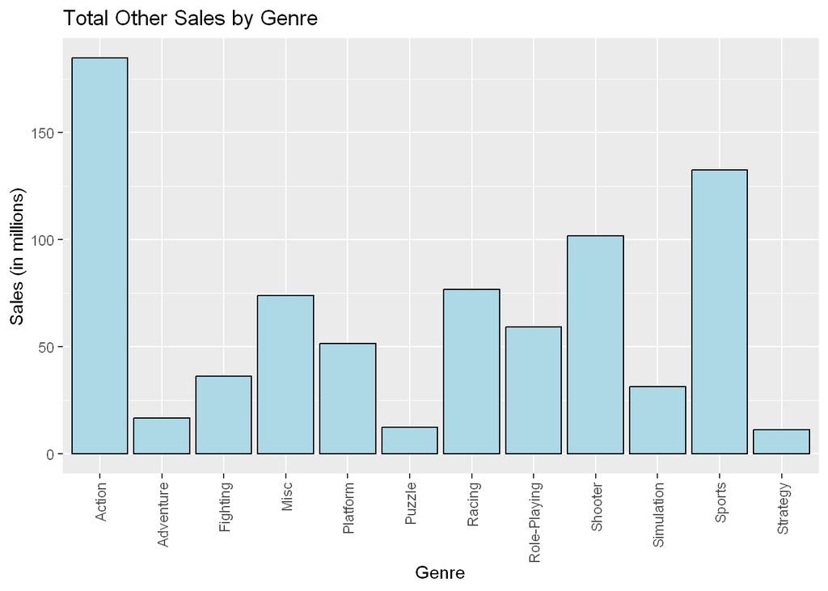

```r
# Other Sales
ggplot(othersales_agg, aes(x = Genre, y = Other_Sales)) + geom_bar(stat = "identity", fill = "lightblue", color = "black") + theme(axis.text.x = element_text(angle = 90, vjust = 0.5, hjust=1)) + labs(x = "Genre", y = "Sales (in millions)", title = "Total Other Sales by Genre")
```

### Data Trends

Total Sales by Year and Geographic Region

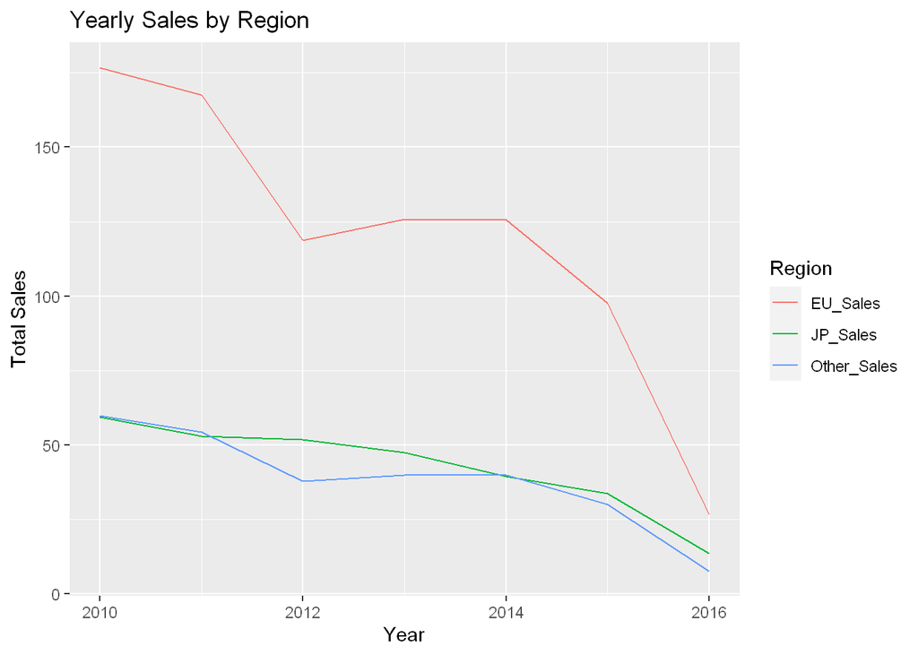

```r
# convert year (currently chr)
vgsales$Year = as.numeric(vgsales$Year)

# 2010 onward filter
vgsales_current = vgsales[vgsales$Year >= 2010, ]

# Calculate total sales using the filtered data frame
total_sales_year = aggregate(cbind(EU_Sales, JP_Sales, Other_Sales) ~ Year, vgsales_current, sum)

ggplot(total_sales_year, aes(x = as.numeric(Year))) + geom_line(aes(y = JP_Sales, color = "JP_Sales")) + geom_line(aes(y = EU_Sales, color = "EU_Sales")) + geom_line(aes(y = Other_Sales, color = "Other_Sales")) + labs(color = "Region", x="Year", y = "Total Sales", title = "Yearly Sales by Region")
```

Total Sales by Platform (2010-2020)

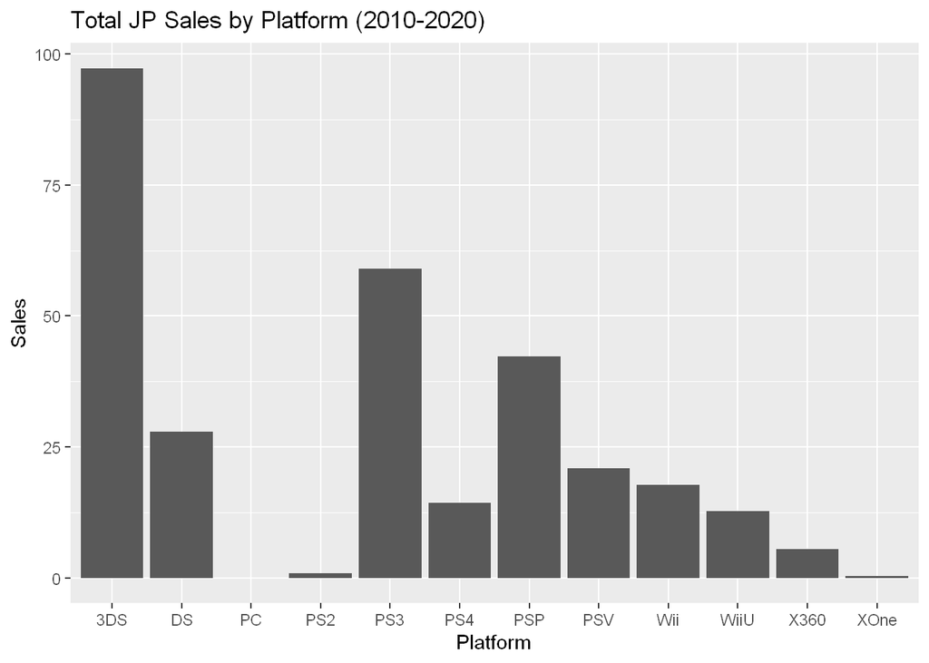

```r
# year filter
vgsales_current = vgsales[vgsales$Year >= 2010 & vgsales$Year <= 2020, ]
total_sales_platform = aggregate(cbind(EU_Sales, JP_Sales, Other_Sales) ~ Platform, vgsales_current, sum)

ggplot(total_sales_platform, aes(x = Platform, y = JP_Sales)) + geom_bar(stat="identity") + theme(axis.text.x = element_text()) + labs(title = "Total JP Sales by Platform (2010-2020)", x = "Platform", y = "Sales")
```

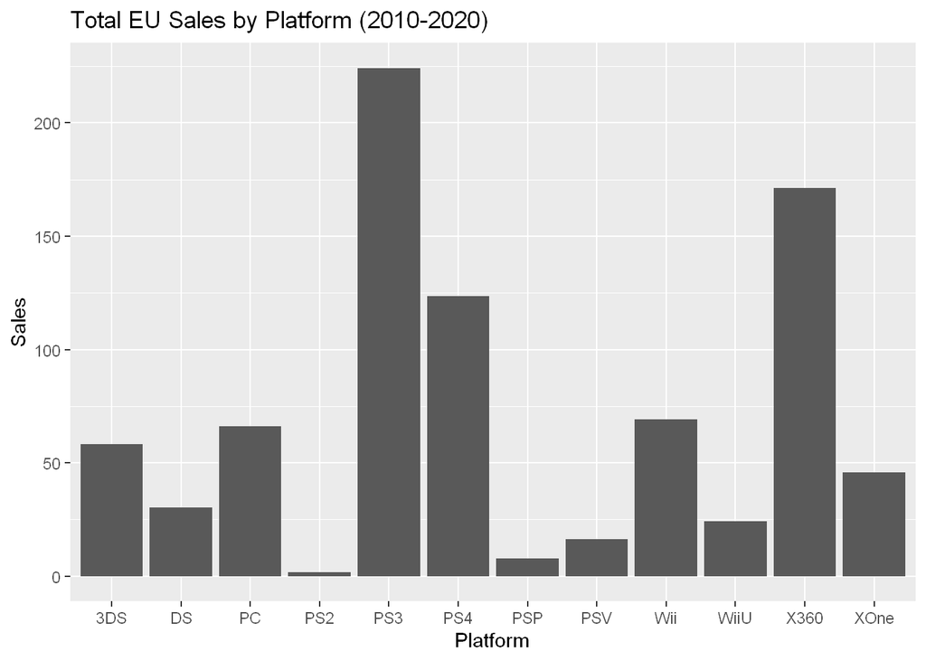

```r
ggplot(total_sales_platform, aes(x = Platform, y = EU_Sales)) + geom_bar(stat="identity") + theme(axis.text.x = element_text()) + labs(title = "Total EU Sales by Platform (2010-2020)", x = "Platform", y = "Sales")
```

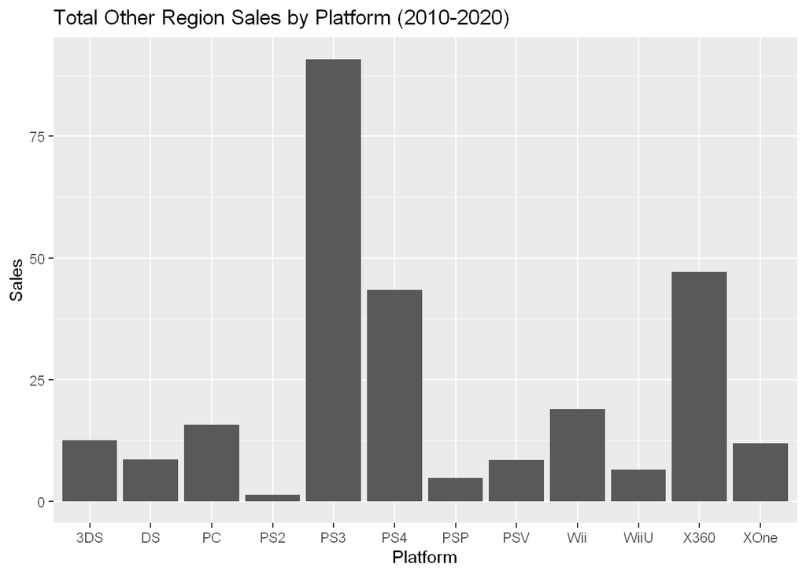

```r
ggplot(total_sales_platform, aes(x = Platform, y = Other_Sales)) + geom_bar(stat="identity") + theme(axis.text.x = element_text()) + labs(title = "Total Other Region Sales by Platform (2010-2020)", x = "Platform", y = "Sales")
```

## Methods

### Pre-Processing

Several of our potential predictors are represented as characters, but we will want to convert them to factor variables. These include:  
* Platform  
* Genre  
* Publisher

Previously we have filtered our dataset to only include games and platforms from 2010 on; next we’ll make the character predictors into factors, then drop levels from factor variables that have no observations (i.e. levels that are only associated with data before 2010, such as Super Nintendo game data).

```r
# Factorize string predictors
vgsales_current$Platform = as.factor(vgsales_current$Platform)
vgsales_current$Genre = as.factor(vgsales_current$Genre)
vgsales_current$Publisher = as.factor(vgsales_current$Publisher)

# Remove unused factor levels
vgsales_modern = droplevels(vgsales_current)
```

```r
# run a correlation matrix on only the numeric predictors
numeric_cols = sapply(vgsales_modern, is.numeric)
numeric_vgsales_modern = vgsales_modern[,numeric_cols]
cor(numeric_vgsales_modern)
```

```
##                     Rank          Year    NA_Sales    EU_Sales    JP_Sales
## Rank          1.00000000  8.865117e-02 -0.47913441 -0.48539903 -0.23418438
## Year          0.08865117  1.000000e+00 -0.04945999  0.01045515  0.01597529
## NA_Sales     -0.47913441 -4.945999e-02  1.00000000  0.77707438  0.24772219
## EU_Sales     -0.48539903  1.045515e-02  0.77707438  1.00000000  0.27864916
## JP_Sales     -0.23418438  1.597529e-02  0.24772219  0.27864916  1.00000000
## Other_Sales  -0.46876627  1.278791e-05  0.76535195  0.95053340  0.21814200
## Global_Sales -0.52047491 -1.763396e-02  0.92742344  0.92927964  0.43725661
##                Other_Sales Global_Sales
## Rank         -4.687663e-01  -0.52047491
## Year          1.278791e-05  -0.01763396
## NA_Sales      7.653520e-01   0.92742344
## EU_Sales      9.505334e-01   0.92927964
## JP_Sales      2.181420e-01   0.43725661
## Other_Sales   1.000000e+00   0.90008382
## Global_Sales  9.000838e-01   1.00000000
```

We have also decided to combine EU_Sales, JP_Sales, and Other_Sales into a new predictor called Non_NA_Sales. This is because sales in different countries are correlated (see correlation table above), and Global_Sales is highly correlated with the others since it is an aggregation, which also includes NA_Sales. I am removing the combined columns for better viewing.

```r
# combine sales predictors into one
Non_NA_Sales = vgsales_modern$EU_Sales + vgsales_modern$JP_Sales + vgsales_modern$Other_Sales
vgs_modern = cbind(vgsales_modern, Non_NA_Sales)
vgs_modern = subset(vgsales_modern, select = -c(EU_Sales, JP_Sales, Other_Sales))

str(vgs_modern)
```

```
## 'data.frame':    5141 obs. of  8 variables:
##  $ Rank        : int  16 17 24 27 30 32 33 34 35 36 ...
##  $ Name        : chr  "Kinect Adventures!" "Grand Theft Auto V" "Grand Theft Auto V" "Pokemon Black/Pokemon White" ...
##  $ Platform    : Factor w/ 12 levels "3DS","DS","PC",..: 11 5 11 2 11 11 1 6 5 11 ...
##  $ Year        : num  2010 2013 2013 2010 2011 ...
##  $ Genre       : Factor w/ 12 levels "Action","Adventure",..: 4 1 1 8 9 9 8 9 9 9 ...
##  $ Publisher   : Factor w/ 265 levels "1C Company","505 Games",..: 152 229 229 171 8 8 171 8 8 8 ...
##  $ NA_Sales    : num  14.97 7.01 9.63 5.57 9.03 ...
##  $ Global_Sales: num  21.8 21.4 16.4 15.3 14.8 ...
```

*Note:* The Year predictor will be tried as a numerical variable, but for our smaller range of years a factor might be more appropriate.

### Model Selection

We will generate several models and compare metrics to give us a starting point on intuition. For all models, `NA_Sales` is the response term and represents the units sold in North America.

```r
all_intr_mod = lm(NA_Sales ~ Platform * Year * Genre * Non_NA_Sales + Publisher, data = vgs_modern)
all_mod = lm(NA_Sales ~ Platform + Year + Genre + Publisher + Non_NA_Sales, data = vgs_modern)
foreign_sales_mod = lm(NA_Sales ~ Non_NA_Sales, data = vgs_modern)
intuitive_mod = lm(NA_Sales ~ Non_NA_Sales * Platform + Non_NA_Sales * Genre + Year, data = vgs_modern)
intuitive_mod2 = lm(NA_Sales ~ Non_NA_Sales * Platform + Non_NA_Sales * Genre + Non_NA_Sales * Publisher + Year, data = vgs_modern)
bic_back_mod = step(all_intr_mod, direction = "backward", trace = FALSE, k = log(nrow(vgs_modern)))
```

The intuitive models above were chosen using experience as a customer of video games and a previous salesman. “intuitive_mod”, posits that there are interactions between global non-NA sales and the platform/genre of the game. Platforms and genres can vary a lot in popularity and so I am accounting for different coefficients needed for the different factor levels.

The 2nd intuitive model, “intuitive_mod2”, is similar to the first but includes an interaction between global non-NA sales and the video game publisher. This is based off of the understanding that there are big-name publishers that always produce more sales (profit not being a factor) and smaller independent publishers with more modest sales. As seen in later tests, this interaction gives the model a large boost in prediction accuracy without making it much more confusing.

With our models generated, let’s get information on violated assumptions before producing results. I’ll use the two models with the best prediction and interpretability combinations (metrics on prediction in later charts).

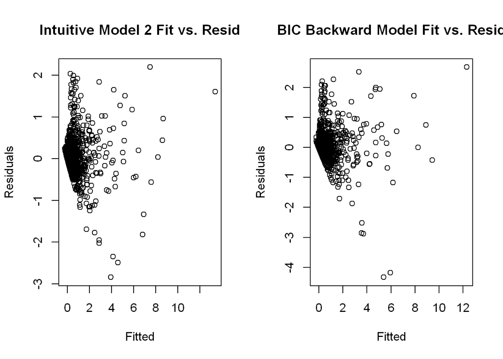

```r
par(mfrow = c(1, 2))
plot(fitted(intuitive_mod2), resid(intuitive_mod2), xlab = "Fitted", ylab = "Residuals", main = "Intuitive Model 2 Fit vs. Resid")
plot(fitted(bic_back_mod), resid(bic_back_mod), xlab = "Fitted", ylab = "Residuals", main = "BIC Backward Model Fit vs. Resid")
```

We see similar charts where there is a lot of variability regardless of fitted magnitude, but the less popularly selling games tend to be easier to predict. This also shows that the distribution of our data is far from normal, which we’ll confirm below.

Now we will test the assumptions of a SLR model. Generating a Q-Q plot for each model yeilds very similar results, so I will only include the graph for the better performing intuitive model 2:

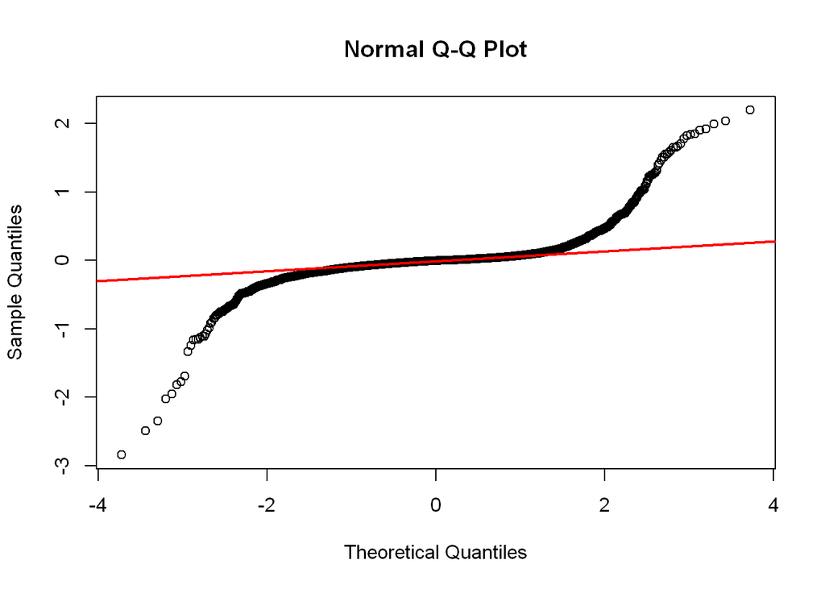

```r
qqnorm(resid(intuitive_mod2))
qqline(resid(intuitive_mod2), col = "red", lwd = 2)
```

```r
stest = shapiro.test(resid(intuitive_mod2)[1:5000])
stest
```

```
##
##  Shapiro-Wilk normality test
##
## data:  resid(intuitive_mod2)[1:5000]
## W = 0.63592, p-value < 2.2e-16
```

Clearly, the errors of our model are not normally distributed, as the plot shows trailing tails at both ends. The Shapiro-Wilkes test concurs by giving an extremely small p-value of 1.933757^{-73}. *Note: we had to exclude 141 of the 5141 residuals dues to limitations of the shapiro.test function*.

## Results

In the following figures, we show bar plots for the $R^2$ values and RMSE. We observe that for “all_intr_mod”, “bic_back_mod” and “intuitive_mod” and “intuitive_mod2” have the highest R^2 values. For the $RMSE$ bar plot, these 4 models also have the lowest RMSE.

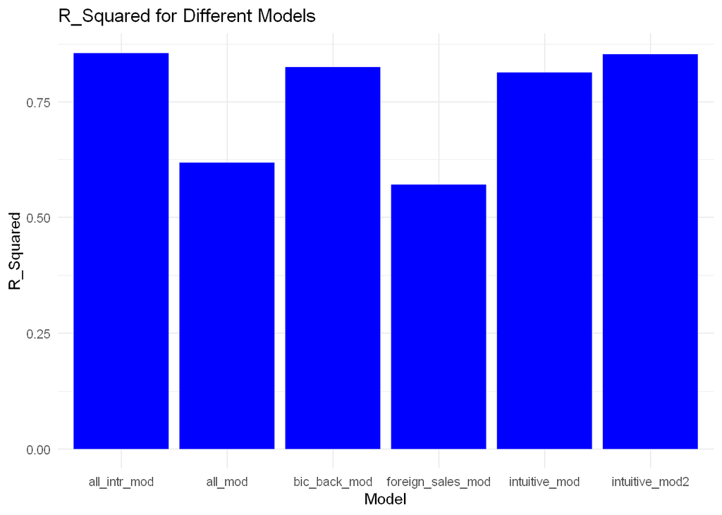

```r
# Given data
data <- data.frame(
  Model = c("all_intr_mod", "all_mod", "foreign_sales_mod", "intuitive_mod", "intuitive_mod2", "bic_back_mod"),
  R_Squared = c(summary(all_intr_mod)$adj.r.squared,
              summary(all_mod)$adj.r.squared,
              summary(foreign_sales_mod)$adj.r.squared,
              summary(intuitive_mod)$adj.r.squared,
              summary(intuitive_mod2)$adj.r.squared,
              summary(bic_back_mod)$adj.r.squared),
  RMSE = c(sqrt(mean(resid(all_intr_mod) ^ 2)),
            sqrt(mean(resid(all_mod) ^ 2)),
            sqrt(mean(resid(foreign_sales_mod) ^ 2)),
            sqrt(mean(resid(intuitive_mod) ^ 2)),
            sqrt(mean(resid(intuitive_mod2) ^ 2)),
            sqrt(mean(resid(bic_back_mod) ^ 2)))
)

# Reshape the data to a long format using gather (tidyr)
data_long <- data %>%
  gather(metric, value, -Model)

# Bar plot for R_Squared
ggplot(data_long[data_long$metric == "R_Squared", ], aes(x = Model, y = value)) +
  geom_col(fill = "blue") +
  labs(x = "Model", y = "R_Squared") +
  ggtitle("R_Squared for Different Models") +
  theme_minimal()
```

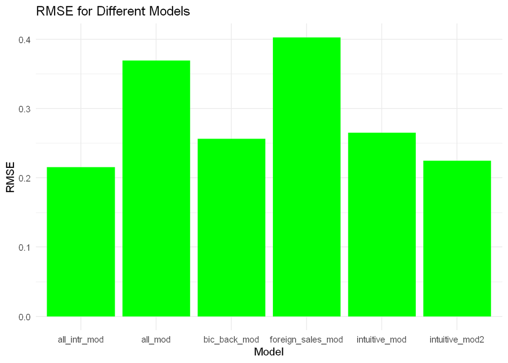

```r
# Bar plot for RMSE
ggplot(data_long[data_long$metric == "RMSE", ], aes(x = Model, y = value)) +
  geom_col(fill = "green") +
  labs(x = "Model", y = "RMSE") +
  ggtitle("RMSE for Different Models") +
  theme_minimal()
```

Looking at the above chart’s values, we see the large model with many fully interacting predictors has the best metrics. This is unsurprising, since adding more and more predictors and interactions generally produces better predictions, but can become confusing and loses ability to interpret meaning between variables.

```r
# Perform ANOVA between all_intr_mod and bic_back_mod
anova1 <- anova(all_intr_mod, bic_back_mod) #(all intr)

# Perform ANOVA between all_intr_mod and intuitive_mod
anova2 <- anova(all_intr_mod,intuitive_mod) # (all_intro)

# Perform ANOVA between all_intr_mod and intuitive_mod2
anova3 <- anova(all_intr_mod, intuitive_mod2)  # (all_intro)

# Perform ANOVA between bic_back_mod and intuitive_mod
anova4 <- anova(bic_back_mod,intuitive_mod) # (back)

# Perform ANOVA between bic_back_mod and intuitive_mod2
anova5 <- anova(bic_back_mod,intuitive_mod2) # (intuitive_mod2)

# Perform ANOVA between intuitive_mod and intuitive_mod2
anova6 <- anova(intuitive_mod, intuitive_mod2) # (intuit 2)

# Extract ANOVA results
print(anova1)
```

```
## Analysis of Variance Table
##
## Model 1: NA_Sales ~ Platform * Year * Genre * Non_NA_Sales + Publisher
## Model 2: NA_Sales ~ Platform + Year + Genre + Non_NA_Sales + Platform:Year +
##     Platform:Non_NA_Sales + Year:Non_NA_Sales + Genre:Non_NA_Sales +
##     Platform:Year:Non_NA_Sales
##   Res.Df    RSS   Df Sum of Sq      F    Pr(>F)
## 1   4364 238.65
## 2   5071 337.15 -707   -98.503 2.5477 < 2.2e-16 ***
## ---
## Signif. codes:  0 '***' 0.001 '**' 0.01 '*' 0.05 '.' 0.1 ' ' 1
```

```r
print(anova2)
```

```
## Analysis of Variance Table
##
## Model 1: NA_Sales ~ Platform * Year * Genre * Non_NA_Sales + Publisher
## Model 2: NA_Sales ~ Non_NA_Sales * Platform + Non_NA_Sales * Genre + Year
##   Res.Df    RSS   Df Sum of Sq      F    Pr(>F)
## 1   4364 238.65
## 2   5094 360.99 -730   -122.34 3.0646 < 2.2e-16 ***
## ---
## Signif. codes:  0 '***' 0.001 '**' 0.01 '*' 0.05 '.' 0.1 ' ' 1
```

```r
print(anova3)
```

```
## Analysis of Variance Table
##
## Model 1: NA_Sales ~ Platform * Year * Genre * Non_NA_Sales + Publisher
## Model 2: NA_Sales ~ Non_NA_Sales * Platform + Non_NA_Sales * Genre + Non_NA_Sales *
##     Publisher + Year
##   Res.Df    RSS   Df Sum of Sq      F   Pr(>F)
## 1   4364 238.65
## 2   4667 259.12 -303   -20.474 1.2356 0.004383 **
## ---
## Signif. codes:  0 '***' 0.001 '**' 0.01 '*' 0.05 '.' 0.1 ' ' 1
```

```r
print(anova4)
```

```
## Analysis of Variance Table
##
## Model 1: NA_Sales ~ Platform + Year + Genre + Non_NA_Sales + Platform:Year +
##     Platform:Non_NA_Sales + Year:Non_NA_Sales + Genre:Non_NA_Sales +
##     Platform:Year:Non_NA_Sales
## Model 2: NA_Sales ~ Non_NA_Sales * Platform + Non_NA_Sales * Genre + Year
##   Res.Df    RSS  Df Sum of Sq      F    Pr(>F)
## 1   5071 337.15
## 2   5094 360.99 -23   -23.838 15.588 < 2.2e-16 ***
## ---
## Signif. codes:  0 '***' 0.001 '**' 0.01 '*' 0.05 '.' 0.1 ' ' 1
```

```r
print(anova5)
```

```
## Analysis of Variance Table
##
## Model 1: NA_Sales ~ Platform + Year + Genre + Non_NA_Sales + Platform:Year +
##     Platform:Non_NA_Sales + Year:Non_NA_Sales + Genre:Non_NA_Sales +
##     Platform:Year:Non_NA_Sales
## Model 2: NA_Sales ~ Non_NA_Sales * Platform + Non_NA_Sales * Genre + Non_NA_Sales *
##     Publisher + Year
##   Res.Df    RSS  Df Sum of Sq      F    Pr(>F)
## 1   5071 337.15
## 2   4667 259.12 404    78.029 3.4786 < 2.2e-16 ***
## ---
## Signif. codes:  0 '***' 0.001 '**' 0.01 '*' 0.05 '.' 0.1 ' ' 1
```

```r
print(anova6)
```

```
## Analysis of Variance Table
##
## Model 1: NA_Sales ~ Non_NA_Sales * Platform + Non_NA_Sales * Genre + Year
## Model 2: NA_Sales ~ Non_NA_Sales * Platform + Non_NA_Sales * Genre + Non_NA_Sales *
##     Publisher + Year
##   Res.Df    RSS  Df Sum of Sq      F    Pr(>F)
## 1   5094 360.99
## 2   4667 259.12 427    101.87 4.2967 < 2.2e-16 ***
## ---
## Signif. codes:  0 '***' 0.001 '**' 0.01 '*' 0.05 '.' 0.1 ' ' 1
```

The “all_intr_mod” model’s improved performance can be attributed to its inclusion of the interaction terms, which allowed for a more accurate and nuanced representation of the relationship between the predictors and the response variable, NA_Sales.